# TASK (dataset: chd)

Amanda Wittendorf

2026-10-02

2026-10-01

## 1. DESKRIPTION ON THE DATASET

# 1. DESKRIPTION ON THE DATASET

The dataset contains measurements a large American study named *The Framingham Heart Study*, whose purpose was to identify factors that could contribute to cardiovascular diseases

- $\text{id}$: individuals ID-number
- $\text{chd}$: cardiovascular disease after 18 years of follow-up (1 = yes, 0 = no)
- $\text{sbp160}$: systolic blood pressure (1 = sbp > 160, 0 = sbp < 160)
- $\text{age}$: individuals age (year)
- $\text{sex}$: gender (1 = male, 2 = female)

## 1. SIMPLE LOGISTIC REGRESSION MODEL

### 1.1 ASSOCIATION BETWEEN SYSTOLIC BLOOD PRESSURE ($\text{sbp160}$) & THE RISK OF GETTING CARDIOVASCULAR DISEASE AFTER 18 YEARS OF FOLLOW-UP ($\text{chd}$)

# 1. SIMPLE LOGISTIC REGRESSION MODEL

## 1.1 ASSOCIATION BETWEEN SYSTOLIC BLOOD PRESSURE ($\text{sbp160}$) & THE RISK OF GETTING CARDIOVASCULAR DISEASE AFTER 18 YEARS OF FOLLOW-UP ($\text{chd}$)

**The model**
$$chd =
\beta_\text{0} + \beta_\text{1} \cdot sbp160$$

```
##
## Table 1: Association between cardiovascular disease and SBP (ref. = <160 mmHg)
## ==========================================
##                   Dependent variable:
##              -----------------------------
##                           chd
## ------------------------------------------
## SBP (>160)              2.48***
##                      (1.85, 3.30)
##
## Intercept               0.19***
##                      (0.16, 0.22)
##
## ------------------------------------------
## Observations             1,363
## ==========================================
## Note:        *p<0.05; **p<0.01; ***p<0.001
```

**INTREPETATION**

### 1.1.1 The corresponding odds ratio for men and women separately

To calculate the OR for the genders separately the function `filter` is included in separate regression model; one for the female, and one for the males.

```
##
## Table 2: Separate regression model (genders)
## ===========================================
##                   Dependent variable:
##              ------------------------------
##                           chd
##               Model (female)  Model (male)
##                    (1)             (2)
## -------------------------------------------
## SBP (<160)       3.36***         2.56***
##                (2.19, 5.15)   (1.66, 3.92)
##
## Intercept        0.11***         0.28***
##                (0.08, 0.14)   (0.23, 0.35)
##
## -------------------------------------------
## Observations       720             643
## ===========================================
## Note:         *p<0.05; **p<0.01; ***p<0.001
```

**INTERPRETATION**

**Intercept:** The same as before but separately for males and females…

**SBP (<160):** The same as before but separately for males and females…

**Effect modification:** When looking at the estimates and comparing it to the crude estimate ($\text{gender}_{crude}$) it appears that elevated systolic blood pressure ($\text{sbp}_{>160}$) has a universal, strong and statistically significant effect on the cardiovascular disease; no matter the gender. However, this is not telling if there is effect modification or not…

## 2. MULTIPLE LOGISTISK REGRESSION MODEL

### 2.1 ASSOCIATION BETWEEN SYSTOLIC BLOOD PRESSURE ($\text{sbp}$), THE RISK OF GETTING CARDIOVASCULAR DISEASE ($\text{chd}$) ADJUSTING FOR GENDERS ($\text{sex}$)

# 2. MULTIPLE LOGISTISK REGRESSION MODEL

## 2.1 ASSOCIATION BETWEEN SYSTOLIC BLOOD PRESSURE ($\text{sbp}$), THE RISK OF GETTING CARDIOVASCULAR DISEASE ($\text{chd}$) ADJUSTING FOR GENDERS ($\text{sex}$)

To evaluate how the two genders ($\text{sex}$) effect the association a multiple logistic regression model, in which $\text{sex}$ is included, is made:
$$\text{chd} = \beta_\text{0} + \beta_\text{1}
\cdot \text{sbp} + \beta_\text{2} \cdot \text{sex}$$
This model is compared to *the simple logistic model* in which $\text{sex}$ isn’t included

```
##
## Table 3: Association between cardiovascular disease, SBP (ref. = >160 mmHg) & gender (ref. = male)
## ==============================================
##                      Dependent variable:
##                 ------------------------------
##                              chd
##                  Simple model   Multiple model
##                       (1)            (2)
## ----------------------------------------------
## SBP (<160)          2.48***        2.93***
##                  (1.85, 3.30)    (2.17, 3.96)
##
## Gender (female)                    0.42***
##                                  (0.31, 0.55)
##
## Intercept           0.19***        0.27***
##                  (0.16, 0.22)    (0.22, 0.33)
##
## ----------------------------------------------
## Observations         1,363          1,363
## ==============================================
## Note:            *p<0.05; **p<0.01; ***p<0.001
```

**INTERPRETATION**

This phenomenon is called confounding, more specific Simpson’s Paradox, and is characterized by;

1. $\text{sex}$ is strongly associated to developing cardiovascular disease $\text{chd}$ e.g. $\text{sex}_{female}$ has significantly lower odds than $\text{sex}_{male}$ independently to $\text{sbp}$.
2. $\text{sex}$ is associated to the SBP-distribution; the genders has different distribution of high SBP $\text{sbp}_{>160}$ and normal SBP $\text{sbp}_{<160}$. *In conclusion* when not adjusting for genders ($\text{sex}$), the effect of high SBP ($\text{sbp}_{>160}$) is underestimated because $\text{sex}_{male}$, with a higher overall risk, and $\text{sex}_{female}$, with a lower overall risk, are mixed together.

##### 2.1.1. CONFOUNDING

To better evaluated if gender ($\text{sex}$) is a confounder to the association, a plot is constructed:

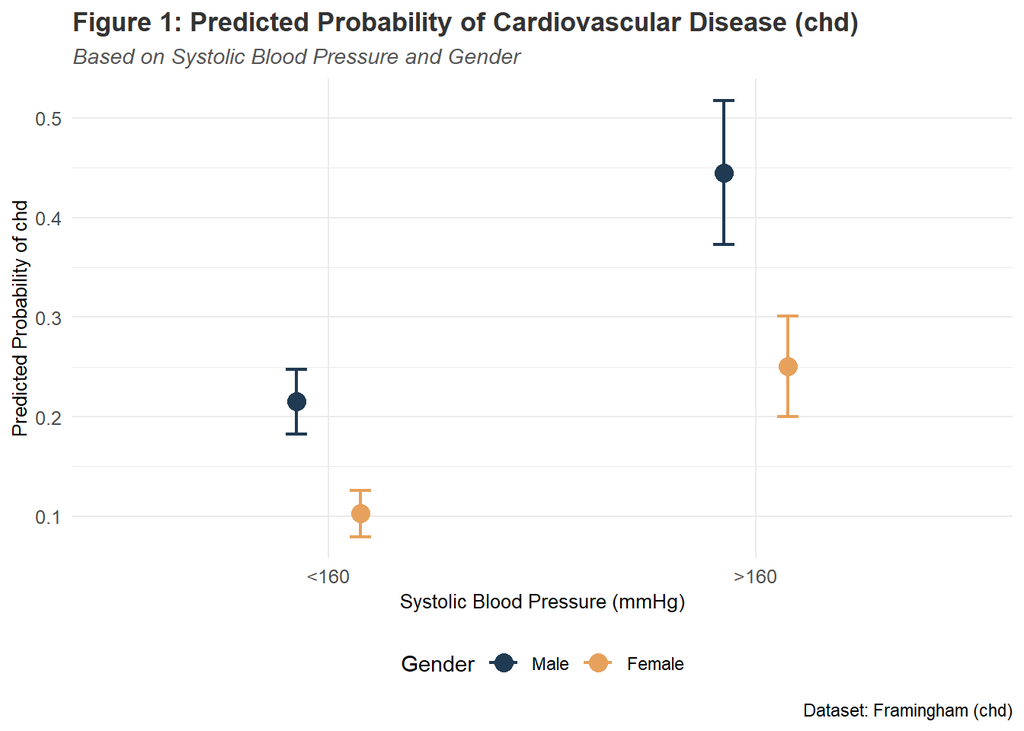

### 2.1.1. CONFOUNDING

To better evaluated if gender ($\text{sex}$) is a confounder to the association, a plot is constructed:

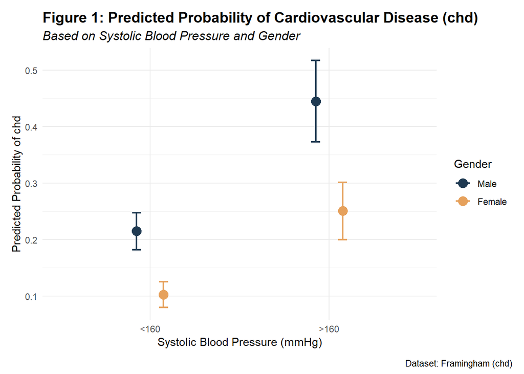

*Figure 1 illustrates that males ($\text{sex}_{male}$) have a significantly higher predicted probability of developing cardiovascular disease $\text{chd}$ compared to females ($\text{sex}_{female}$) across both SBP-strata*, as indicated by the non-overlapping 95% CIs between genders within each group.

However, the relative increase in risk from normal to elevated SBP develops in a similar parallel fashion for both men and women. This parallel trend visually confirms that sex ($\text{sex}$) acts as a confounder because it shifts the baseline risk rather than modifying the effect of SBP itself.

##### 2.1.2. EFFECT MODIFICATION

**Model**
$$\text{chd} =
\beta_\text{0} + \beta_\text{1} \cdot \text{sbp} + \beta_\text{2} \cdot
\text{sex} + \beta_\text{3} \cdot \text{sbp} \cdot
\text{sex}$$

```
##
## Table 4: Association between cardiovascular disease and SBP (ref. = <160 mmHg) adjusted for gender (ref. = male)
## ==================================================
##                           Dependent variable:
##                      -----------------------------
##                                   chd
## --------------------------------------------------
## SBP (>160)                      2.56***
##                              (1.66, 3.92)
##
## Gender (ref. = Male)            0.38***
##                              (0.26, 0.54)
##
## Interaction term                 1.31
##                              (0.72, 2.40)
##
## Intercept                       0.28***
##                              (0.23, 0.35)
##
## --------------------------------------------------
## Observations                     1,363
## ==================================================
## Note:                *p<0.05; **p<0.01; ***p<0.001
```

**INTERPRETATION**

**Reference group:** Men who have normal SBP ($\text{sbp}_{<160}$)

**SBP (>160):** The effect of a high blood pressure ($\text{sbp}_{>160}$) for men is (1.66; 3.92, p < 0.001) times higher then men with normal blood pressure.

**Gender (ref. = Male):** The odds for developing CHD for women with normal blood pressure compared to men - this is significantly (0.26; 0.54, p < 0.001) times less.

**Interaction term:** How the effect of high blood pressure changes when looking at women instead of men; women has a non-significant higher increased odds of (0.72; 2.4, p 0.379) compared to men.

In addition, two are plots are being constructed;

1. Predicted Probabillities
2. Difference in probabillities

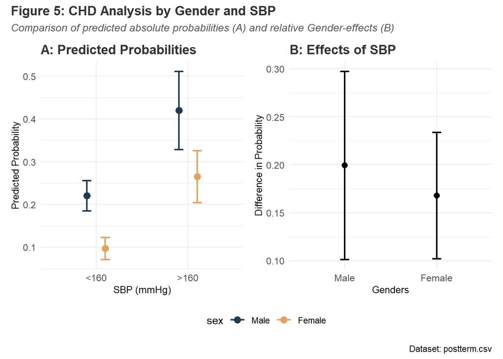

**Figure 5A** shows that the predicted probabilities of CHD are consistently higher for males than for females across both blood pressure levels, reflecting the significant effect of gender (OR = 0.38). **Figure 5B** visualizes the risk increase (difference in probability) caused by high blood pressure for each gender. *The heavily overlapping confidence intervals in Figure 5B visually confirm that the effect of SBP does not differ significantly between men and women, which perfectly mirrors the non-significant interaction term* (OR = 1.31) in the model.

In conclusion, it doesn’t appear that Gender has a effect modification for the association..

#### 2.1.3. SPECIFIC EFFECT FOR EACH GENDER

```
##          Identity Probability CI_low CI_high       p
## 1   Male, SBP<160        0.22   0.19    0.26 < 0.001
## 2   Male, SBP>160        0.42   0.33    0.51 < 0.001
## 3 Female, SBP<160        0.10   0.07    0.12 < 0.001
## 4 Female, SBP>160        0.26   0.20    0.33 < 0.001
```

**INTERPRETATION**

The results correlate with the effects estimated in Table 4 because the estimates for the males are generally higher than the women no matter blood pressure.

## 2.2 ASSOCIATION BETWEEN SBP ($\text{sbp}$) & THE RISK OF GETTING CARDIOVASCULAR DISEASE ($\text{chd}$) ADJUSTING FOR GENDERS ($\text{sex}$) & AGE ($\text{age}$)

**Model**
$$\text{chd} =
\beta_\text{0} + \beta_\text{1} \cdot \text{sbp} + \beta_\text{2} \cdot
\text{sex} + \beta_\text{3} \cdot \text{age}$$

```
##
## Table 3: Association between cardiovascular disease & SBP (ref. = >160 mmHg) adjusting for gender (ref. = male) & age
## =============================================
##                      Dependent variable:
##                 -----------------------------
##                              chd
## ---------------------------------------------
## SBP (>160)                 2.75***
##                         (2.03, 3.73)
##
## Gender (female)            0.41***
##                         (0.31, 0.55)
##
## Age (year)                 1.06***
##                         (1.03, 1.09)
##
## Intercept                  0.01***
##                         (0.003, 0.06)
##
## ---------------------------------------------
## Observations                1,363
## =============================================
## Note:           *p<0.05; **p<0.01; ***p<0.001
```

**INTERPRETATION**

**Reference group:** A male ($\text{sex}_{male}$) with normal blood pressure ($\text{sbp}_{<160}$) with an age ($\text{age}$) of 0 years old.

**Intercept:** The odds for getting cardiovascular disease ($\text{chd}$) for the reference group..

**SBP (>160):** When adjusting for gender ($\text{sex}$) and age ($\text{age}$), individuals with high SBP ($\text{sbp}_{>160}$) is (2.03; 3.73, p < 0.001) times higher odds of getting cardiovascular disease ($\text{chd}$) than individuals with normal SBP ($\text{sbp}_{<160}$).

**Age (year):** For each year one individual gets older, the odds for evolving cardiovascular diseases ($\text{chp}$) with (1.03; 1.09, p < 0.001) when adjusting for gender ($\text{sex}$) and SBP ($\text{sbp}$) .

### 2.2.3 THE SPECIFIC EFFECT FOR TWO INDIVIDUALS & THE OR BETWEEN THE TWO

1. 60-year-old men with a systolic blood pressure < 160 mmHg.
2. 50-year-old women with a systolic blood pressure > 160 mmHg.

[output not shown]